# Week 5 - Introduction to Data Analysis

ETC1010-5510

15 March, 2021

# Exercise 3: Visualise Missing Values

#### **Estimated time: 20 min**

```r
library(naniar)
```

## Section A: Visualising all of missingness

It can be difficult to get a handle on where the missing values are in your data, and here is where visualisation can really help.

The function `vis_miss()` creates an overview visualisation of the missingness in the data. It also has options to cluster rows based on missingness, using `cluster = TRUE`; as well as options for sorting the columns, from most missing to least missing (`sort_miss = TRUE`).

### Instructions: Section A

Using the `riskfactors` dataset from `naniar`:

- Use `vis_miss()` to visualise the missingness in the data.
- Use `vis_miss()` with `cluster = TRUE` to explore some clusters of missingness.
- Use `vis_miss()` and sort the missings with `sort_miss` to arrange the columns by missingness.
- Use the options `cluster = TRUE` and `sort_miss = TRUE` inside of `vis_miss` to cluster and sort missing values

## Answer the following questions:

### Q1A. Visualise all of the missingness in the `riskfactors` dataset. Use `vis_miss`

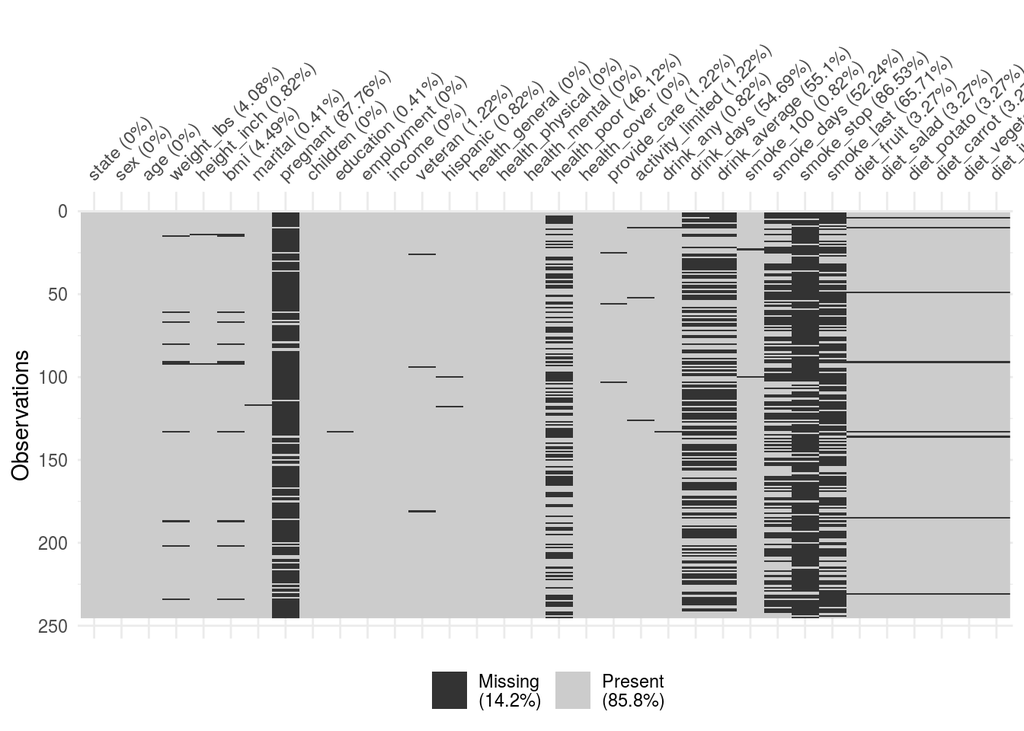

```r
vis_miss(riskfactors)
```

### Q2A. Visualise and cluster all of the missingness in the `riskfactors` dataset. Use option `cluster`

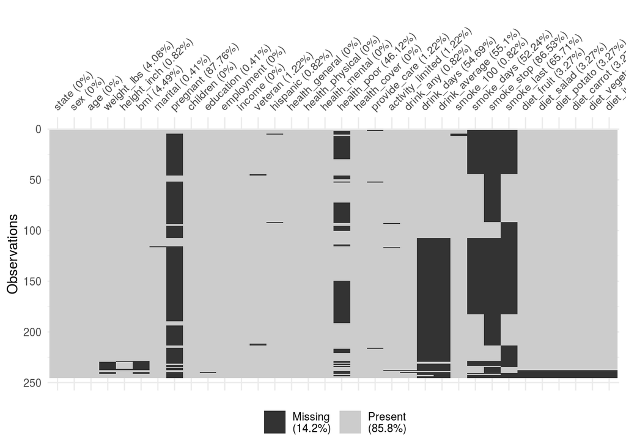

```r
vis_miss(riskfactors, cluster  = TRUE)
```

### Q3A. visualise and sort the columns by missingness in the `riskfactors` dataset. Use option `sort`

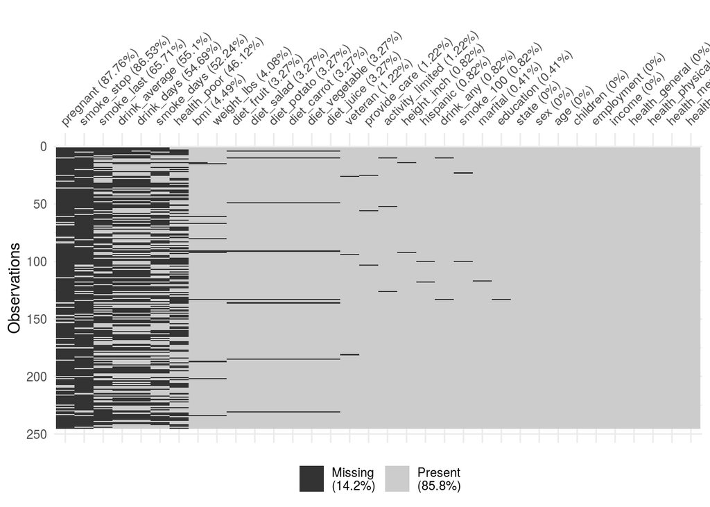

```r
vis_miss(riskfactors, sort = TRUE)
```

## Section B: Visualising missing cases and variables

To get a clear picture of the missingness across variables and cases, use `gg_miss_var()` and `gg_miss_case()`. These are the visual counterpart to `miss_var_summary()` and `miss_case_summary()`.

These can be split up into multiple plots with one for each category by choosing a variable to facet by.

### Instructions: Section B

Using the `riskfactors` dataset:

- Visualise the number of missings in cases using `gg_miss_case()`.
- Explore the number of missings in cases using `gg_miss_case()` and facet by the variable `education`.
- Visualise the number of missings in variables using `gg_miss_var()`.
- Explore the number of missings in variables using `gg_miss_var()` and facet by the variable `education`.

What do you notice in the visualisations of the whole data compared to the faceting?

## Answer the following questions:

### Q1B. Visualise the number of missings in cases using `gg_miss_case()`

Use `gg_miss_case(riskfactors)` to get started, and `gg_miss_case(riskfactors, facet = education)` to facet by education.

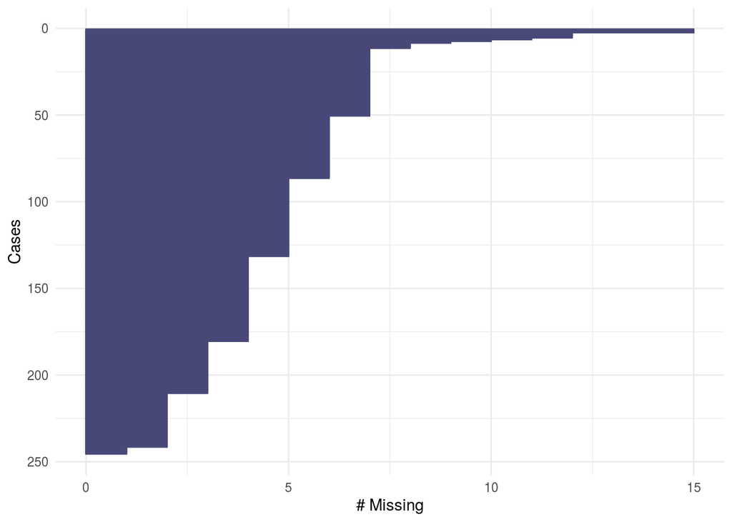

```r
gg_miss_case(riskfactors)
```

### Q2B. Explore the number of missings in cases using `gg_miss_case()` and facet by the variable `education`.

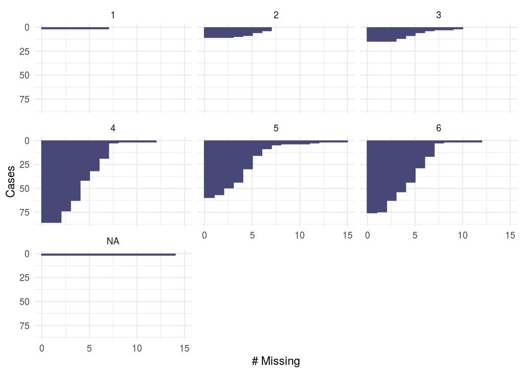

```r
gg_miss_case(riskfactors, facet = education)
```

> Note: You might get a warning that says Factor `education` contains implicit NA, consider using `forcats::fct_explicit_na` This is OK - it is to do with how NA values are recorded in the data, and is not an error.

### Q3B. Visualise the number of missings in variables using `gg_miss_var()`

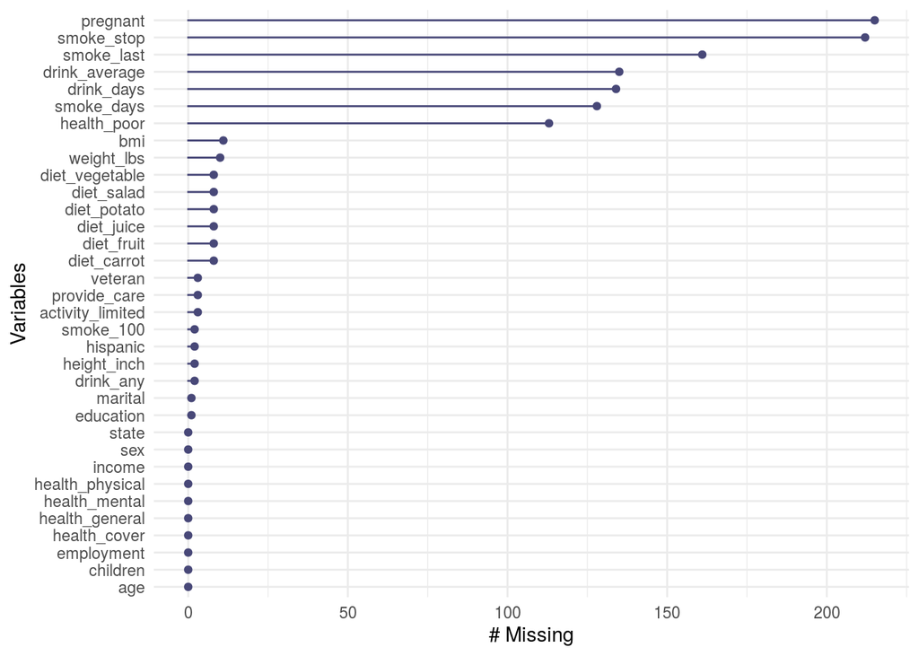

```r
gg_miss_var(riskfactors)
```

### Q4B. Explore the number of missings in variables using `gg_miss_var()` and facet by the variable `education`.

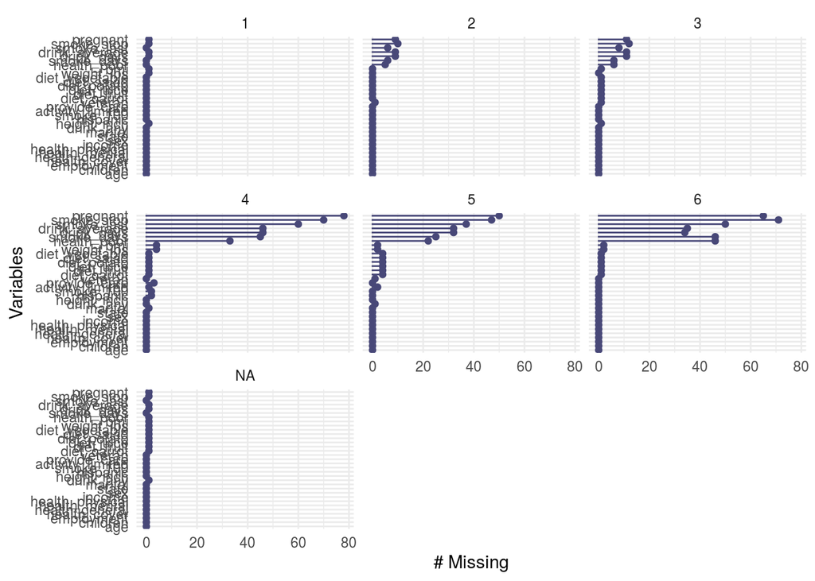

```r
gg_miss_var(riskfactors, facet = education)
```

### Q5B. With the riskfactors dataset, explore how the missingness changes across the `marital` variable using gg_miss_fct()

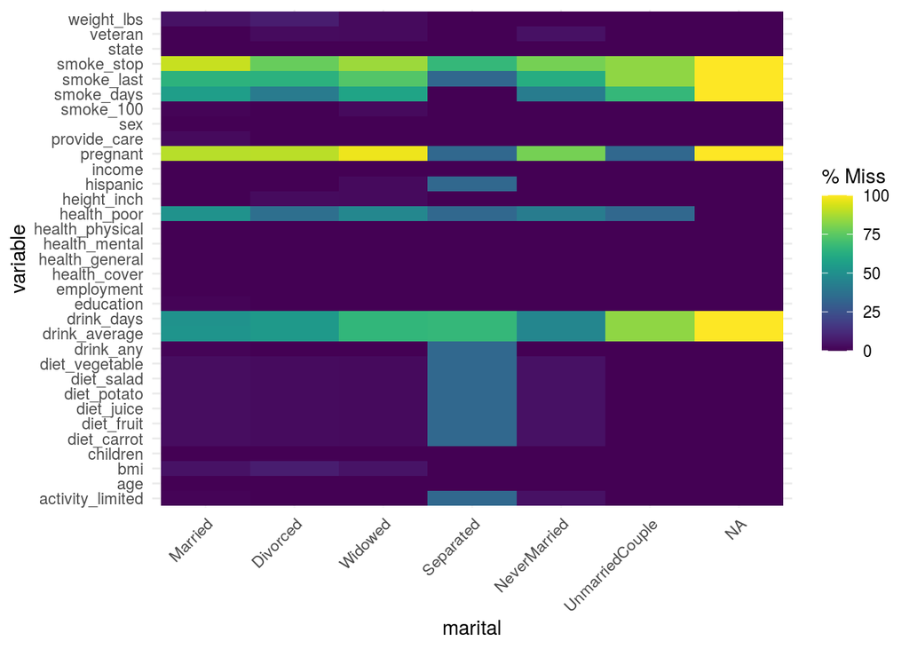

```r
gg_miss_fct(x = riskfactors, fct = marital)
```

## This is the End of Exercise 3

# Extra bits if interested

Let’s practice a few different ways to visualise patterns of missingness using:

- `gg_miss_upset()` to give an overall pattern of missingness.
- `gg_miss_fct()` for a dataset that has a factor of interest: marriage.
- and `gg_miss_span()` to explore the missingness in a time series dataset.

What do you notice with the missingness and the facetting in the data?

- Explore missingness pattern of the `airquality` dataset with `gg_miss_upset()`.
- Explore how the missingness changes in the `riskfactors` dataset across the `marital` variable using `gg_miss_fct()`.

Using the `pedestrian` dataset:

### Using the airquality dataset, explore the missingness pattern using `gg_miss_upset()`

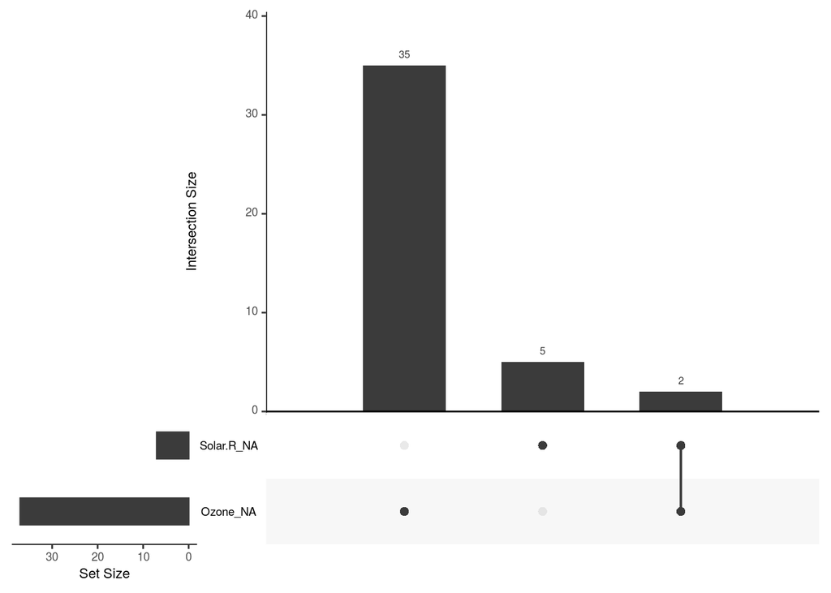

```r
gg_miss_upset(airquality)
```

### Using the pedestrian dataset, explore how the missingness of hourly_counts changes over a span of 3000

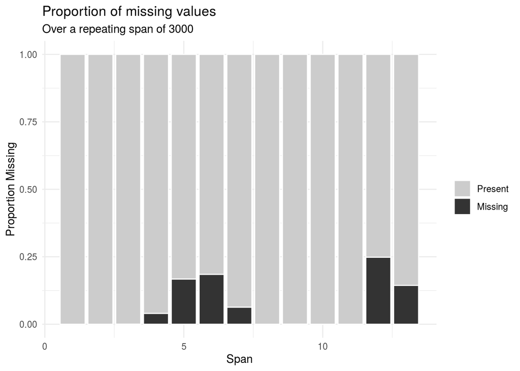

```r
gg_miss_span(pedestrian, var = hourly_counts, span_every = 3000)
```

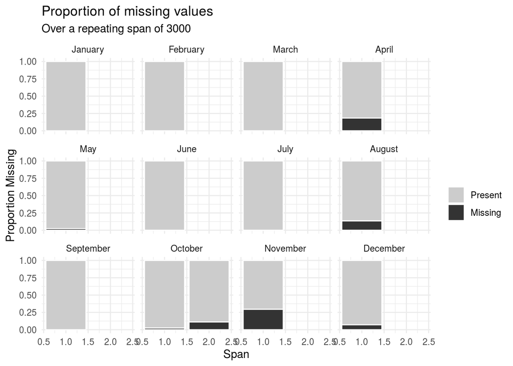

```r
gg_miss_span(pedestrian, var = hourly_counts, span_every = 3000, facet = month)
```